# Skin releases and champion balance: general overview

Construction and exploration of the first analysis cohort

## Objective

The main hypothesis is that champions receive buffs shortly before a skin is released, potentially to increase skin sales. A secondary question is whether this pattern is stronger for champions that are already popular.

This first report constructs one row per non-base skin release. It is descriptive: because every row is a skin release, it cannot by itself establish whether buffs are more common than during comparable periods without a skin release. A later modelling step should add champion-specific control dates and account for repeated releases for the same champion.

The analysis uses the following conventions:

- skin releases before 2011 are excluded;
- skins marked as cancelled and skins without a release date are excluded;
- skins released from the champion’s release date through 60 days afterward are excluded;
- performance is linearly interpolated 30 days before and 14 days after the release date;
- buffs are counted from 42 days before through the release date, including changes shipped on the release date;
- nerfs are counted from the day after release through 42 days after release;
- only buffs and nerfs classified as `CERTAIN` or `VERY_CERTAIN` are counted;
- a skin is excluded if the champion has any classified rework within 60 days on either side of its release;
- multiple skins for the same champion on the same date remain separate rows because the unit is a skin release.

The graph source contains dates but no release times. Interpolation therefore evaluates each target date at midnight UTC.

## Setup

This report deliberately uses `data.table` and base R graphics rather than the tidyverse.

Install the three required packages once before rendering:

```r
install.packages(c("DBI", "RSQLite", "data.table"))
```

```r
required_packages <- c("DBI", "RSQLite", "data.table")
missing_packages <- required_packages[
  !vapply(required_packages, requireNamespace, logical(1L), quietly = TRUE)
]

if (length(missing_packages) > 0L) {
  stop(
    "Install the required R packages first: ",
    paste(sprintf("install.packages('%s')", missing_packages), collapse = "; ")
  )
}

library(data.table)

locate_database <- function(configured_path = NULL) {
  candidates <- if (!is.null(configured_path) && nzchar(configured_path)) {
    configured_path
  } else {
    c(
      "data/lol_skin_release_statistics.sqlite3",
      "../../data/lol_skin_release_statistics.sqlite3"
    )
  }
  existing <- candidates[file.exists(candidates)]
  if (length(existing) == 0L) {
    stop("SQLite database not found. Render from the repository root or set params.database.")
  }
  normalizePath(existing[[1L]], mustWork = TRUE)
}

database_path <- locate_database(params$database)
connection <- DBI::dbConnect(
  RSQLite::SQLite(),
  dbname = database_path,
  flags = RSQLite::SQLITE_RO
)

pre_performance_days <- 30L
post_performance_days <- 14L
balance_window_days <- 42L
rework_window_days <- 60L
champion_release_window_days <- 60L
accepted_confidence <- c("CERTAIN", "VERY_CERTAIN")
```

## Read the normalized source tables

`champion_id` below is Riot’s stable numeric champion ID. `skin_id` is the Wiki/Riot skin ID rather than the SQLite surrogate key.

```r
skins <- as.data.table(DBI::dbGetQuery(connection, "
  SELECT
    champions.game_id AS champion_id,
    champions.name AS champion_name,
    skins.wiki_skin_id AS skin_id,
    skins.display_name AS skin_name,
    skins.release_date AS skin_release_date,
    base_skin.release_date AS champion_release_date
  FROM skins
  JOIN champions ON champions.id = skins.champion_id
  JOIN skins AS base_skin
    ON base_skin.champion_id = champions.id
   AND base_skin.is_base = 1
  WHERE skins.is_base = 0
    AND skins.release_date IS NOT NULL
    AND skins.release_date >= '2011-01-01'
    AND skins.availability <> 'Canceled'
  ORDER BY skins.release_date, champions.name, skins.wiki_skin_id
"))

graph_points <- as.data.table(DBI::dbGetQuery(connection, "
  SELECT
    champions.game_id AS champion_id,
    graph_series.metric,
    graph_points.observed_at_ms,
    graph_points.value
  FROM graph_points
  JOIN graph_series ON graph_series.id = graph_points.graph_series_id
  JOIN champions ON champions.id = graph_series.champion_id
  WHERE graph_series.metric IN ('win_rate', 'popularity')
  ORDER BY champions.game_id, graph_series.metric, graph_points.observed_at_ms
"))

classified_changes <- as.data.table(DBI::dbGetQuery(connection, "
  SELECT
    champions.game_id AS champion_id,
    patch_events.patch_id,
    patch_events.effective_date,
    classifications.label AS classification_label,
    classifications.confidence
  FROM classifications
  JOIN patch_entries ON patch_entries.id = classifications.patch_entry_id
  JOIN patch_events ON patch_events.id = patch_entries.patch_event_id
  JOIN champions ON champions.id = patch_events.champion_id
  WHERE classifications.label IN ('buff', 'nerf', 'rework')
"))

DBI::dbDisconnect(connection)

skins[, skin_release_date := as.IDate(skin_release_date)]
skins[, champion_release_date := as.IDate(champion_release_date)]
graph_points[, observed_at_ms := as.numeric(observed_at_ms)]
classified_changes[, effective_date := as.IDate(effective_date)]
classified_changes[, effective_day := as.integer(effective_date)]
```

## Interpolate performance around each release

Linear interpolation uses only observations from the same champion and metric. Targets before the first or after the last available observation remain missing rather than being extrapolated.

```r
graph_points[, series_key := paste(champion_id, metric, sep = "::")]
graph_series <- split(
  graph_points[, .(observed_at_ms, value)],
  graph_points$series_key
)

interpolate_value <- function(champion, metric_name, target_date) {
  series <- graph_series[[paste(champion, metric_name, sep = "::")]]
  if (is.null(series) || nrow(series) < 2L) {
    return(NA_real_)
  }

  target_ms <- as.numeric(target_date) * 86400000
  if (target_ms < series$observed_at_ms[[1L]] || target_ms > series$observed_at_ms[[nrow(series)]]) {
    return(NA_real_)
  }

  stats::approx(
    x = series$observed_at_ms,
    y = series$value,
    xout = target_ms,
    method = "linear",
    ties = "ordered",
    rule = 1L
  )$y
}

skin_windows <- copy(skins)
skin_windows[, win_rate_1m_before := mapply(
  function(champion, release_date) {
    interpolate_value(champion, "win_rate", release_date - pre_performance_days)
  },
  champion_id,
  skin_release_date
)]
skin_windows[, win_rate_2w_after := mapply(
  function(champion, release_date) {
    interpolate_value(champion, "win_rate", release_date + post_performance_days)
  },
  champion_id,
  skin_release_date
)]
skin_windows[, popularity_1m_before := mapply(
  function(champion, release_date) {
    interpolate_value(champion, "popularity", release_date - pre_performance_days)
  },
  champion_id,
  skin_release_date
)]
skin_windows[, popularity_2w_after := mapply(
  function(champion, release_date) {
    interpolate_value(champion, "popularity", release_date + post_performance_days)
  },
  champion_id,
  skin_release_date
)]
```

## Count nearby balance changes

Counts refer to individually classified patch-history entries. Distinct patch counts are retained as diagnostics so that one patch containing several changes can be distinguished from several separate buff or nerf patches.

```r
changes_by_champion <- split(classified_changes, classified_changes$champion_id)

count_changes <- function(champion, target_label, first_date, last_date, distinct_patches = FALSE) {
  changes <- changes_by_champion[[as.character(champion)]]
  if (is.null(changes)) {
    return(0L)
  }

  selected <- changes[
    classification_label == target_label &
      confidence %chin% accepted_confidence &
      !is.na(effective_day) &
      effective_day >= as.integer(first_date) &
      effective_day <= as.integer(last_date)
  ]
  if (distinct_patches) {
    return(uniqueN(selected$patch_id))
  }
  nrow(selected)
}

skin_windows[, buff_entries_6w_before := mapply(
  function(champion, release_date) {
    count_changes(
      champion,
      "buff",
      release_date - balance_window_days,
      release_date
    )
  },
  champion_id,
  skin_release_date
)]
skin_windows[, buff_patches_6w_before := mapply(
  function(champion, release_date) {
    count_changes(
      champion,
      "buff",
      release_date - balance_window_days,
      release_date,
      distinct_patches = TRUE
    )
  },
  champion_id,
  skin_release_date
)]
skin_windows[, nerf_entries_6w_after := mapply(
  function(champion, release_date) {
    count_changes(
      champion,
      "nerf",
      release_date + 1L,
      release_date + balance_window_days
    )
  },
  champion_id,
  skin_release_date
)]
skin_windows[, nerf_patches_6w_after := mapply(
  function(champion, release_date) {
    count_changes(
      champion,
      "nerf",
      release_date + 1L,
      release_date + balance_window_days,
      distinct_patches = TRUE
    )
  },
  champion_id,
  skin_release_date
)]
```

## Exclude releases close to champion releases or reworks

The base skin’s release date is the champion release date. A non-base skin launched on that date or during the next 60 days is excluded because newly released champions are generally less stable and always launch with at least one skin.

The confidence filter is unnecessary for reworks in the current database because every rework classification is already `CERTAIN` or `VERY_CERTAIN`. The exclusion nevertheless uses all rework labels so it remains conservative if the classifier is rerun later.

```r
rework_dates <- unique(
  classified_changes[
    classification_label == "rework" & !is.na(effective_date),
    .(champion_id, effective_date)
  ]
)
reworks_by_champion <- split(as.integer(rework_dates$effective_date), rework_dates$champion_id)

has_nearby_rework <- function(champion, release_date) {
  dates <- reworks_by_champion[[as.character(champion)]]
  !is.null(dates) && any(abs(dates - as.integer(release_date)) <= rework_window_days)
}

skin_windows[, excluded_for_rework := mapply(
  has_nearby_rework,
  champion_id,
  skin_release_date
)]
skin_windows[, days_since_champion_release := as.integer(
  skin_release_date - champion_release_date
)]
skin_windows[, excluded_for_champion_release :=
  days_since_champion_release >= 0L &
  days_since_champion_release <= champion_release_window_days]
skin_windows[, complete_performance_window := complete.cases(
  win_rate_1m_before,
  win_rate_2w_after,
  popularity_1m_before,
  popularity_2w_after
)]

analysis_data <- skin_windows[
  !excluded_for_champion_release &
    !excluded_for_rework &
    complete_performance_window
]
analysis_data[, `:=`(
  win_rate_change = win_rate_2w_after - win_rate_1m_before,
  popularity_change = popularity_2w_after - popularity_1m_before,
  any_buff_6w_before = buff_entries_6w_before > 0L,
  any_nerf_6w_after = nerf_entries_6w_after > 0L,
  release_year = as.integer(format(skin_release_date, "%Y"))
)]
analysis_data[, popularity_percentile := frank(
  popularity_1m_before,
  ties.method = "average"
) / .N]
analysis_data[, popularity_quartile := cut(
  popularity_percentile,
  breaks = c(0, 0.25, 0.5, 0.75, 1),
  labels = c("Q1: least popular", "Q2", "Q3", "Q4: most popular"),
  include.lowest = TRUE
)]
setorder(analysis_data, skin_release_date, champion_name, skin_id)
```

## Cohort checks and exported matrix

```r
cohort_flow <- data.table(
  stage = c(
    "Dated, non-base, non-cancelled releases from 2011",
    "After excluding releases within 60 days of champion release",
    "After excluding releases within 60 days of a rework",
    "After requiring all four interpolated measurements"
  ),
  releases = c(
    nrow(skin_windows),
    skin_windows[excluded_for_champion_release == FALSE, .N],
    skin_windows[
      excluded_for_champion_release == FALSE & excluded_for_rework == FALSE,
      .N
    ],
    nrow(analysis_data)
  )
)
print(cohort_flow)
```

```
                                                         stage releases
                                                        <char>    <int>
1:           Dated, non-base, non-cancelled releases from 2011     1746
2: After excluding releases within 60 days of champion release     1606
3:         After excluding releases within 60 days of a rework     1575
4:          After requiring all four interpolated measurements     1360
```

```r
quality_checks <- data.table(
  check = c(
    "Unique champion/skin IDs",
    "Missing requested matrix values",
    "Negative balance-entry counts"
  ),
  failures = c(
    nrow(analysis_data) - uniqueN(analysis_data, by = c("champion_id", "skin_id")),
    sum(!complete.cases(analysis_data[, .(
      champion_id,
      skin_id,
      skin_release_date,
      win_rate_1m_before,
      win_rate_2w_after,
      popularity_1m_before,
      popularity_2w_after,
      buff_entries_6w_before,
      nerf_entries_6w_after
    )])),
    analysis_data[
      buff_entries_6w_before < 0L | nerf_entries_6w_after < 0L,
      .N
    ]
  )
)
print(quality_checks)
```

```
                             check failures
                            <char>    <int>
1:        Unique champion/skin IDs        0
2: Missing requested matrix values        0
3:   Negative balance-entry counts        0
```

```r
analysis_columns <- c(
  "champion_id",
  "champion_name",
  "skin_id",
  "skin_name",
  "skin_release_date",
  "win_rate_1m_before",
  "win_rate_2w_after",
  "popularity_1m_before",
  "popularity_2w_after",
  "buff_entries_6w_before",
  "buff_patches_6w_before",
  "nerf_entries_6w_after",
  "nerf_patches_6w_after",
  "win_rate_change",
  "popularity_change",
  "any_buff_6w_before",
  "any_nerf_6w_after",
  "popularity_quartile"
)
analysis_matrix <- analysis_data[, ..analysis_columns]
print(head(analysis_matrix, 10L))
```

```
    champion_id champion_name skin_id    skin_name skin_release_date
          <int>        <char>   <int>       <char>            <IDat>
 1:         134        Syndra       2    Atlantean        2014-04-29
 2:          24           Jax       8       SKT T1        2014-05-04
 3:          64       Lee Sin       6       SKT T1        2014-05-04
 4:          67         Vayne       5       SKT T1        2014-05-04
 5:         238           Zed       2       SKT T1        2014-05-04
 6:         143          Zyra       3       SKT T1        2014-05-04
 7:          80      Pantheon       6 Dragonslayer        2014-05-14
 8:         127     Lissandra       2  Blade Queen        2014-05-26
 9:         267          Nami       2 River Spirit        2014-06-01
10:         133         Quinn       2   Woad Scout        2014-06-09
    win_rate_1m_before win_rate_2w_after popularity_1m_before
                 <num>             <num>                <num>
 1:           49.21656          49.04128             3.615877
```

[output cut: 45 more lines]

```r
if (isTRUE(params$export_csv)) {
  export_directory <- file.path(dirname(database_path), "analysis")
  dir.create(export_directory, recursive = TRUE, showWarnings = FALSE)
  export_path <- file.path(export_directory, "skin_release_matrix.csv")
  fwrite(analysis_matrix, export_path)
  cat("Analysis matrix written to:", export_path, "\n")
}
```

```
Analysis matrix written to: /mnt/c/users/yannicksuter/repositories/lol-skin-release-statistics/data/analysis/skin_release_matrix.csv
```

## General buff and nerf statistics

The overall table covers every buff and nerf classification in the database regardless of whether a skin was released nearby. It reports both the complete classified counts and the high-confidence subset used by the analysis.

```r
overall_balance_statistics <- classified_changes[
  classification_label %chin% c("buff", "nerf"),
  .(
    classified_entries = .N,
    confident_entries = sum(confidence %chin% accepted_confidence),
    confident_share = mean(confidence %chin% accepted_confidence),
    entries_with_known_date = sum(!is.na(effective_date)),
    champions = uniqueN(champion_id),
    distinct_patch_ids = uniqueN(patch_id)
  ),
  by = classification_label
]
setorder(overall_balance_statistics, classification_label)
print(overall_balance_statistics)
```

```
   classification_label classified_entries confident_entries confident_share
                 <char>              <int>             <int>           <num>
1:                 buff              14200             14169       0.9978169
2:                 nerf               9961              9947       0.9985945
   entries_with_known_date champions distinct_patch_ids
                     <int>     <int>              <int>
1:                   14114       173                447
2:                    9917       173                443
```

### Baseline by patch year

The yearly baseline is independent of skin releases. It uses patch effective dates and the same confidence threshold as the skin-window counts, making the annual buff/nerf comparison directly relevant to the later analysis. Entries whose Wiki history has no known effective date remain in the overall table above but cannot be assigned to a year.

```r
general_balance_by_year_long <- classified_changes[
  classification_label %chin% c("buff", "nerf") & !is.na(effective_date),
  .(
    classified_entries = .N,
    confident_entries = sum(confidence %chin% accepted_confidence)
  ),
  by = .(
    patch_year = as.integer(format(effective_date, "%Y")),
    classification_label
  )
]
setorder(general_balance_by_year_long, patch_year, classification_label)
print(general_balance_by_year_long)
```

```
    patch_year classification_label classified_entries confident_entries
         <int>               <char>              <int>             <int>
 1:       2009                 buff                640               635
 2:       2009                 nerf                449               449
 3:       2010                 buff                656               651
 4:       2010                 nerf                521               521
 5:       2011                 buff                612               608
 6:       2011                 nerf                418               415
 7:       2012                 buff                565               562
 8:       2012                 nerf                322               320
 9:       2013                 buff                408               406
10:       2013                 nerf                367               366
11:       2014                 buff                601               600
12:       2014                 nerf                406               405
13:       2015                 buff                640               639
```

[output cut: 24 more lines]

```r
general_balance_by_year <- dcast(
  general_balance_by_year_long,
  patch_year ~ classification_label,
  value.var = "confident_entries",
  fill = 0L
)
general_balance_by_year[, `:=`(
  buff_minus_nerf = buff - nerf,
  buff_to_nerf_ratio = fifelse(nerf == 0L, NA_real_, buff / nerf)
)]
print(general_balance_by_year)
```

```
Key: <patch_year>
    patch_year  buff  nerf buff_minus_nerf buff_to_nerf_ratio
         <int> <int> <int>           <int>              <num>
 1:       2009   635   449             186           1.414254
 2:       2010   651   521             130           1.249520
 3:       2011   608   415             193           1.465060
 4:       2012   562   320             242           1.756250
 5:       2013   406   366              40           1.109290
 6:       2014   600   405             195           1.481481
 7:       2015   639   533             106           1.198874
 8:       2016   708   586             122           1.208191
 9:       2017  1107   578             529           1.915225
10:       2018   794   613             181           1.295269
11:       2019   924   612             312           1.509804
12:       2020   813   515             298           1.578641
13:       2021   738   548             190           1.346715
14:       2022  1614   862             752           1.872390
15:       2023   932   698             234           1.335244
16:       2024  1118   830             288           1.346988
17:       2025   702   588             114           1.193878
18:       2026   532   464              68           1.146552
```

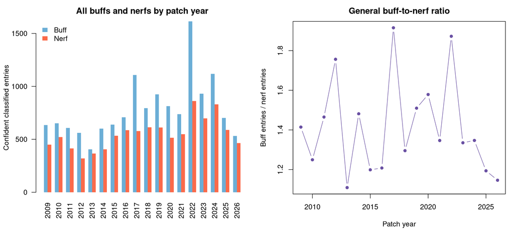

```r
old_parameters <- par(mfrow = c(1, 2), mar = c(4.8, 4.2, 2.5, 1))

barplot(
  t(as.matrix(general_balance_by_year[, .(buff, nerf)])),
  beside = TRUE,
  names.arg = general_balance_by_year$patch_year,
  col = c("#6baed6", "#fb6a4a"),
  border = NA,
  las = 2,
  ylab = "Confident classified entries",
  main = "All buffs and nerfs by patch year"
)
legend(
  "topleft",
  legend = c("Buff", "Nerf"),
  fill = c("#6baed6", "#fb6a4a"),
  border = NA,
  bty = "n"
)

plot(
  general_balance_by_year$patch_year,
  general_balance_by_year$buff_to_nerf_ratio,
  type = "b",
  pch = 16,
  col = "#6a51a3",
  xlab = "Patch year",
  ylab = "Buff entries / nerf entries",
  main = "General buff-to-nerf ratio"
)
abline(h = 1, lty = 2, col = "grey35")
```

```r
par(old_parameters)
```

### Counts in skin-release windows

These counts are conditional on the analysis cohort. Because windows can overlap—and because multiple skins can share a champion and release date—the totals are counts relative to skin releases rather than counts of unique underlying balance entries.

```r
skin_window_balance_statistics <- rbindlist(list(
  analysis_data[, .(
    classification = "buff before release",
    total_entries = sum(buff_entries_6w_before),
    total_distinct_patch_occurrences = sum(buff_patches_6w_before),
    mean_entries_per_release = mean(buff_entries_6w_before),
    median_entries_per_release = median(buff_entries_6w_before),
    maximum_entries_per_release = max(buff_entries_6w_before),
    releases_with_at_least_one = sum(any_buff_6w_before),
    share_of_releases_with_at_least_one = mean(any_buff_6w_before)
  )],
  analysis_data[, .(
    classification = "nerf after release",
    total_entries = sum(nerf_entries_6w_after),
    total_distinct_patch_occurrences = sum(nerf_patches_6w_after),
    mean_entries_per_release = mean(nerf_entries_6w_after),
    median_entries_per_release = median(nerf_entries_6w_after),
    maximum_entries_per_release = max(nerf_entries_6w_after),
    releases_with_at_least_one = sum(any_nerf_6w_after),
    share_of_releases_with_at_least_one = mean(any_nerf_6w_after)
  )]
))
print(skin_window_balance_statistics)
```

```
        classification total_entries total_distinct_patch_occurrences
                <char>         <int>                            <int>
1: buff before release          1057                              488
2:  nerf after release           547                              295
   mean_entries_per_release median_entries_per_release
                      <num>                      <num>
1:                0.7772059                          0
2:                0.4022059                          0
   maximum_entries_per_release releases_with_at_least_one
                         <int>                      <int>
1:                          26                        436
2:                          10                        255
   share_of_releases_with_at_least_one
                                 <num>
1:                           0.3205882
2:                           0.1875000
```

## Descriptive overview

```r
summary_by_quartile <- analysis_data[, .(
  skin_releases = .N,
  champions = uniqueN(champion_id),
  share_with_buff_before = mean(any_buff_6w_before),
  mean_buff_entries_before = mean(buff_entries_6w_before),
  mean_win_rate_change = mean(win_rate_change),
  mean_popularity_change = mean(popularity_change),
  share_with_nerf_after = mean(any_nerf_6w_after)
), by = popularity_quartile]
print(summary_by_quartile)
```

```
   popularity_quartile skin_releases champions share_with_buff_before
                <fctr>         <int>     <int>                  <num>
1:   Q1: least popular           340       106              0.3558824
2:    Q4: most popular           340        65              0.3500000
3:                  Q3           340       115              0.2705882
4:                  Q2           340       122              0.3058824
   mean_buff_entries_before mean_win_rate_change mean_popularity_change
                      <num>                <num>                  <num>
1:                1.1000000          0.103589002              0.8744153
2:                0.7588235         -0.028499317              1.4069465
3:                0.6117647          0.006709475              1.0419428
4:                0.6382353         -0.025187863              0.8469643
   share_with_nerf_after
                   <num>
1:             0.1617647
2:             0.2235294
3:             0.1794118
4:             0.1852941
```

```r
overall_summary <- analysis_data[, .(
  skin_releases = .N,
  champions = uniqueN(champion_id),
  first_release = min(skin_release_date),
  last_release = max(skin_release_date),
  share_with_buff_before = mean(any_buff_6w_before),
  share_with_nerf_after = mean(any_nerf_6w_after),
  median_win_rate_change = median(win_rate_change),
  median_popularity_change = median(popularity_change)
)]
print(overall_summary)
```

```
   skin_releases champions first_release last_release share_with_buff_before
           <int>     <int>        <IDat>       <IDat>                  <num>
1:          1360       171    2014-04-29   2026-08-12              0.3205882
   share_with_nerf_after median_win_rate_change median_popularity_change
                   <num>                  <num>                    <num>
1:                0.1875            -0.02438878                0.5438014
```

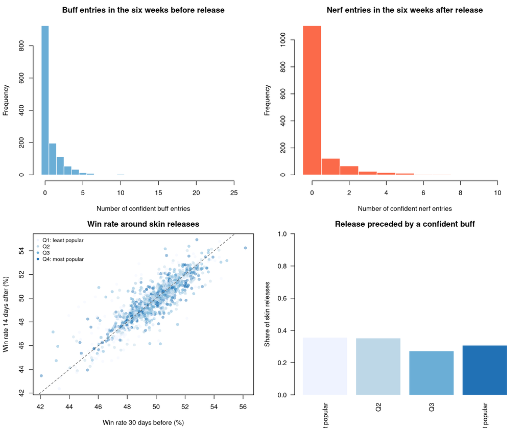

```r
old_parameters <- par(mfrow = c(2, 2), mar = c(4.2, 4.2, 2.5, 1))

hist(
  analysis_data$buff_entries_6w_before,
  breaks = seq(-0.5, max(analysis_data$buff_entries_6w_before) + 0.5, by = 1),
  main = "Buff entries in the six weeks before release",
  xlab = "Number of confident buff entries",
  col = "#6baed6",
  border = "white"
)

hist(
  analysis_data$nerf_entries_6w_after,
  breaks = seq(-0.5, max(analysis_data$nerf_entries_6w_after) + 0.5, by = 1),
  main = "Nerf entries in the six weeks after release",
  xlab = "Number of confident nerf entries",
  col = "#fb6a4a",
  border = "white"
)

quartile_colours <- c("#eff3ff", "#bdd7e7", "#6baed6", "#2171b5")
point_colours <- adjustcolor(
  quartile_colours[as.integer(analysis_data$popularity_quartile)],
  alpha.f = 0.45
)
plot(
  analysis_data$win_rate_1m_before,
  analysis_data$win_rate_2w_after,
  pch = 16,
  col = point_colours,
  xlab = "Win rate 30 days before (%)",
  ylab = "Win rate 14 days after (%)",
  main = "Win rate around skin releases"
)
abline(a = 0, b = 1, lty = 2, col = "grey35")
legend(
  "topleft",
  legend = levels(analysis_data$popularity_quartile),
  col = quartile_colours,
  pch = 16,
  bty = "n",
  cex = 0.8
)

buff_share <- analysis_data[, mean(any_buff_6w_before), by = popularity_quartile]
barplot(
  height = buff_share$V1,
  names.arg = levels(analysis_data$popularity_quartile),
  ylim = c(0, 1),
  col = quartile_colours,
  border = NA,
  las = 2,
  ylab = "Share of skin releases",
  main = "Release preceded by a confident buff"
)
```

```r
par(old_parameters)
```

## Results by release year

Annual summaries help reveal whether a pooled relationship is driven by a particular period. Years before the graph history begins do not appear because the cohort requires both pre- and post-release performance measurements. The latest year may also be incomplete.

```r
yearly_summary <- analysis_data[, .(
  skin_releases = .N,
  champions = uniqueN(champion_id),
  total_buff_entries_before = sum(buff_entries_6w_before),
  total_nerf_entries_after = sum(nerf_entries_6w_after),
  share_with_buff_before = mean(any_buff_6w_before),
  share_with_nerf_after = mean(any_nerf_6w_after),
  mean_win_rate_change = mean(win_rate_change),
  mean_popularity_change = mean(popularity_change)
), by = release_year]
setorder(yearly_summary, release_year)
print(yearly_summary)
```

```
    release_year skin_releases champions total_buff_entries_before
           <int>         <int>     <int>                     <int>
 1:         2014            47        46                        26
 2:         2015            93        85                        59
 3:         2016            73        69                        35
 4:         2017            73        66                        78
 5:         2018            85        74                        53
 6:         2019            99        75                        94
 7:         2020           137       114                       125
 8:         2021           142       108                        87
 9:         2022           156       117                       152
10:         2023           143       113                       129
11:         2024           124        96                       103
12:         2025           113        99                        76
13:         2026            75        69                        40
```

[output cut: 30 more lines]

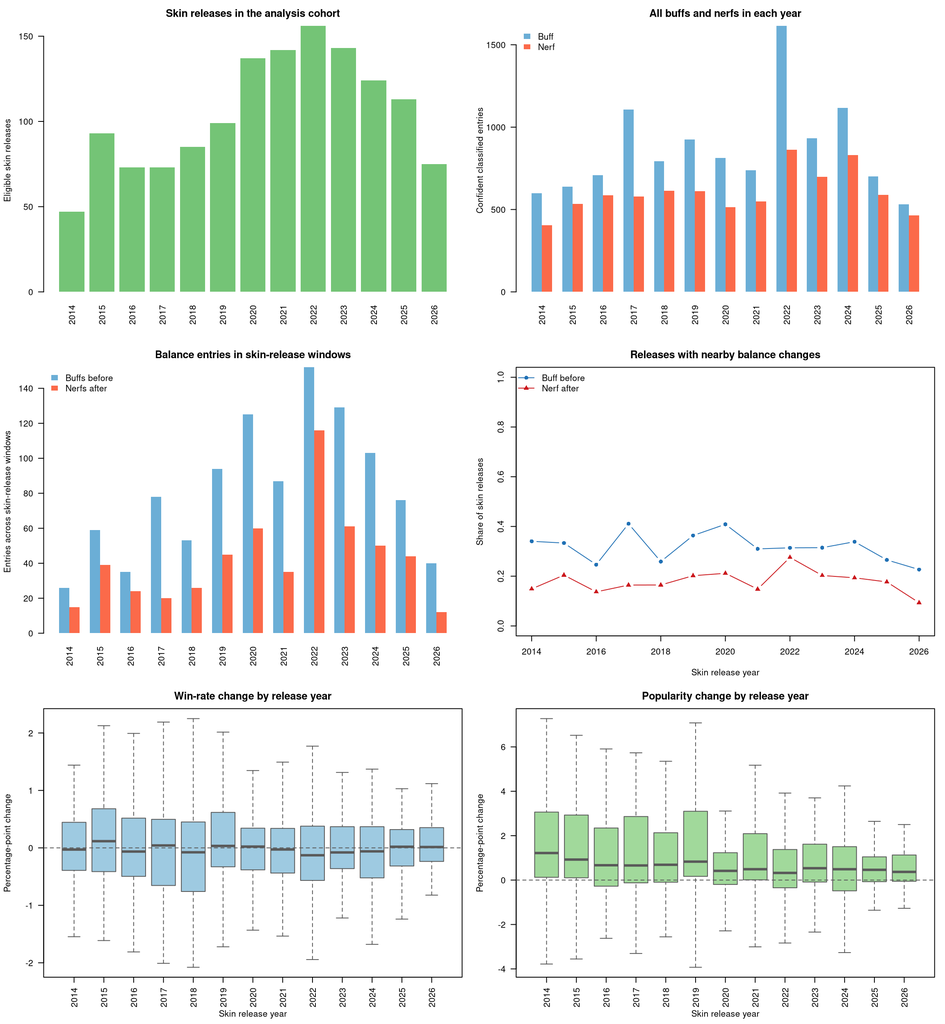

```r
old_parameters <- par(mfrow = c(3, 2), mar = c(4.5, 4.2, 2.5, 1))
year_labels <- yearly_summary$release_year
general_yearly_panel <- general_balance_by_year[match(year_labels, patch_year)]

barplot(
  yearly_summary$skin_releases,
  names.arg = year_labels,
  col = "#74c476",
  border = NA,
  las = 2,
  ylab = "Eligible skin releases",
  main = "Skin releases in the analysis cohort"
)

barplot(
  t(as.matrix(general_yearly_panel[, .(buff, nerf)])),
  beside = TRUE,
  names.arg = year_labels,
  col = c("#6baed6", "#fb6a4a"),
  border = NA,
  las = 2,
  ylab = "Confident classified entries",
  main = "All buffs and nerfs in each year"
)
legend(
  "topleft",
  legend = c("Buff", "Nerf"),
  fill = c("#6baed6", "#fb6a4a"),
  border = NA,
  bty = "n"
)

barplot(
  rbind(
    yearly_summary$total_buff_entries_before,
    yearly_summary$total_nerf_entries_after
  ),
  beside = TRUE,
  names.arg = year_labels,
  col = c("#6baed6", "#fb6a4a"),
  border = NA,
  las = 2,
  ylab = "Entries across skin-release windows",
  main = "Balance entries in skin-release windows"
)
legend(
  "topleft",
  legend = c("Buffs before", "Nerfs after"),
  fill = c("#6baed6", "#fb6a4a"),
  border = NA,
  bty = "n"
)

matplot(
  year_labels,
  cbind(
    yearly_summary$share_with_buff_before,
    yearly_summary$share_with_nerf_after
  ),
  type = "b",
  pch = c(16, 17),
  lty = 1,
  col = c("#2171b5", "#cb181d"),
  ylim = c(0, 1),
  xlab = "Skin release year",
  ylab = "Share of skin releases",
  main = "Releases with nearby balance changes"
)
legend(
  "topleft",
  legend = c("Buff before", "Nerf after"),
  col = c("#2171b5", "#cb181d"),
  pch = c(16, 17),
  lty = 1,
  bty = "n"
)

boxplot(
  win_rate_change ~ factor(release_year),
  data = analysis_data,
  outline = FALSE,
  col = "#9ecae1",
  border = "grey35",
  las = 2,
  xlab = "Skin release year",
  ylab = "Percentage-point change",
  main = "Win-rate change by release year"
)
abline(h = 0, lty = 2, col = "grey35")

boxplot(
  popularity_change ~ factor(release_year),
  data = analysis_data,
  outline = FALSE,
  col = "#a1d99b",
  border = "grey35",
  las = 2,
  xlab = "Skin release year",
  ylab = "Percentage-point change",
  main = "Popularity change by release year"
)
abline(h = 0, lty = 2, col = "grey35")
```

```r
par(old_parameters)
```

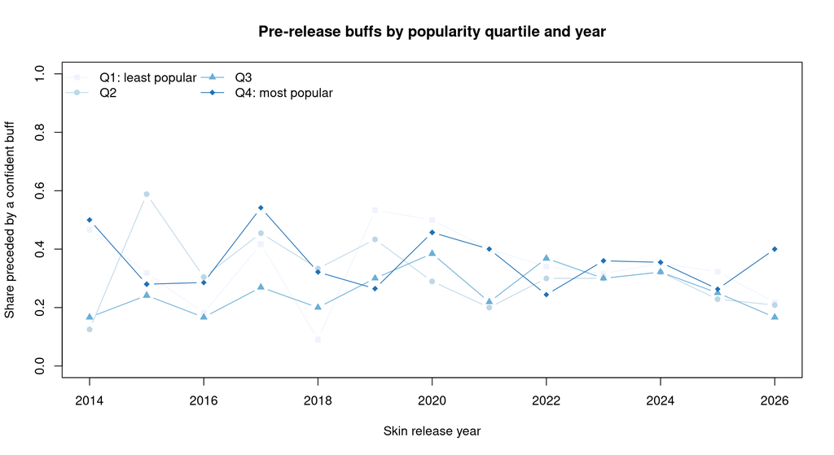

```r
yearly_popularity <- analysis_data[, .(
  share_with_buff_before = mean(any_buff_6w_before),
  skin_releases = .N
), by = .(release_year, popularity_quartile)]
yearly_popularity_wide <- dcast(
  yearly_popularity,
  release_year ~ popularity_quartile,
  value.var = "share_with_buff_before"
)

matplot(
  yearly_popularity_wide$release_year,
  as.matrix(
    yearly_popularity_wide[, setdiff(names(yearly_popularity_wide), "release_year"), with = FALSE]
  ),
  type = "b",
  pch = 15:18,
  lty = 1,
  col = quartile_colours,
  ylim = c(0, 1),
  xlab = "Skin release year",
  ylab = "Share preceded by a confident buff",
  main = "Pre-release buffs by popularity quartile and year"
)
legend(
  "topleft",
  legend = names(yearly_popularity_wide)[-1L],
  col = quartile_colours,
  pch = 15:18,
  lty = 1,
  bty = "n",
  ncol = 2
)
```

## Interpretation and next modelling step

The plots describe what happens around skin releases and whether the descriptive pattern differs with pre-release popularity. They are not yet a causal test. Calendar time, champion-specific balancing frequency, repeated skins for the same champion, patch cadence, and general changes in Riot’s release practices can all confound the comparison.

A suitable next step is a matched case-control or event-study design. For each real release, sample control dates for the same champion from periods with sufficient graph coverage and no nearby skin or rework, then compare the probability or count of preceding buffs. Champion and calendar-period effects can subsequently be included in a conditional logistic, count, or mixed-effects model.